# 434finalproj

# Introduction

Imports

```r
library(leaps)
library(glmnet)
library(dplyr)
library(gam)
library(splines)
library(gbm)
library(ggplot2)
library(nnet)
library(boot)
library(MASS)
library(tree)
library(randomForest)
library(caret)
```

# Data Cleaning

Our dataset has many variables that caused instances of high linear dependance or other errors when designing our models, so we only kept variables that we though would be pertinent to our study.

```r
loans = read.csv("loan.csv", nrows = 10000)
```

```r
head(loans)
```

```
##   id member_id loan_amnt funded_amnt funded_amnt_inv       term int_rate
## 1 NA        NA      2500        2500            2500  36 months    13.56
## 2 NA        NA     30000       30000           30000  60 months    18.94
## 3 NA        NA      5000        5000            5000  36 months    17.97
## 4 NA        NA      4000        4000            4000  36 months    18.94
## 5 NA        NA     30000       30000           30000  60 months    16.14
## 6 NA        NA      5550        5550            5550  36 months    15.02
##   installment grade sub_grade      emp_title emp_length home_ownership
## 1       84.92     C        C1           Chef  10+ years           RENT
## 2      777.23     D        D2    Postmaster   10+ years       MORTGAGE
## 3      180.69     D        D1 Administrative    6 years       MORTGAGE
## 4      146.51     D        D2  IT Supervisor  10+ years       MORTGAGE
## 5      731.78     C        C4       Mechanic  10+ years       MORTGAGE
## 6      192.45     C        C3   Director COE  10+ years       MORTGAGE
##   annual_inc verification_status  issue_d loan_status pymnt_plan url desc
```

[output cut: 223 more lines]

Remove columns from dataset that have missing values in at least half the rows of the dataset. Also remove columns from data set where the values of each row are all the same.

```r
loans <- loans[, colSums(is.na(loans)) < nrow(loans)/2]
loans <- Filter(function(x) length(unique(x))>1, loans)
head(loans)
```

```
##   loan_amnt funded_amnt funded_amnt_inv       term int_rate installment grade
## 1      2500        2500            2500  36 months    13.56       84.92     C
## 2     30000       30000           30000  60 months    18.94      777.23     D
## 3      5000        5000            5000  36 months    17.97      180.69     D
## 4      4000        4000            4000  36 months    18.94      146.51     D
## 5     30000       30000           30000  60 months    16.14      731.78     C
## 6      5550        5550            5550  36 months    15.02      192.45     C
##   sub_grade      emp_title emp_length home_ownership annual_inc
## 1        C1           Chef  10+ years           RENT      55000
## 2        D2    Postmaster   10+ years       MORTGAGE      90000
## 3        D1 Administrative    6 years       MORTGAGE      59280
## 4        D2  IT Supervisor  10+ years       MORTGAGE      92000
## 5        C4       Mechanic  10+ years       MORTGAGE      57250
## 6        C3   Director COE  10+ years       MORTGAGE     152500
##   verification_status loan_status            purpose                   title
```

[output cut: 125 more lines]

Keep columns that we believe to be pertinent to interest rate and not linearly dependent. Also removed rows with N/A.

```r
loans<-loans[ , which(names(loans) %in% c("funded_amnt", "term", "int_rate", "emp_length", "home_ownership", "annual_inc", "verification_status",  "purpose", "delinq_2yrs", "earliest_cr_line", "open_acc", "pub_rec", "revol_bal", "initial_list_status", "acc_open_past_24mths", "avg_cur_bal", "num_sats", "pub_rec_bankruptcies"))]

# turn date format into an int
dates = paste('01', loans$earliest_cr_line)
loans$earliest_cr_line = as.Date(dates, format = "%d %b-%Y")
loans$earliest_cr_line = as.integer(loans$earliest_cr_line)

# emp_length had some N/A stored as a string
loans = loans[!(loans$emp_length=="n/a"),]
loans$emp_length <- factor(loans$emp_length)
loans <- na.omit(loans)

head(loans)
```

```
##   funded_amnt       term int_rate emp_length home_ownership annual_inc
## 1        2500  36 months    13.56  10+ years           RENT      55000
## 2       30000  60 months    18.94  10+ years       MORTGAGE      90000
## 3        5000  36 months    17.97    6 years       MORTGAGE      59280
## 4        4000  36 months    18.94  10+ years       MORTGAGE      92000
## 5       30000  60 months    16.14  10+ years       MORTGAGE      57250
## 6        5550  36 months    15.02  10+ years       MORTGAGE     152500
##   verification_status            purpose delinq_2yrs earliest_cr_line open_acc
## 1        Not Verified debt_consolidation           0            11413        9
## 2     Source Verified debt_consolidation           0             6360       13
## 3     Source Verified debt_consolidation           0            15065        8
## 4     Source Verified debt_consolidation           0            13180       10
## 5        Not Verified debt_consolidation           0            11292       12
## 6        Not Verified        credit_card           0            11931       18
##   pub_rec revol_bal initial_list_status acc_open_past_24mths avg_cur_bal
## 1       1      4341                   w                    9        1878
## 2       1     12315                   w                   10       24763
## 3       0      4599                   w                    4       18383
## 4       0      5468                   w                    5       30505
## 5       0       829                   w                    9        9667
## 6       0     53854                   w                    8       40338
##   num_sats pub_rec_bankruptcies
## 1        9                    1
## 2       13                    1
## 3        8                    0
## 4       10                    0
## 5       12                    0
## 6       18                    0
```

# Data Exploration

### term vs. int_rate

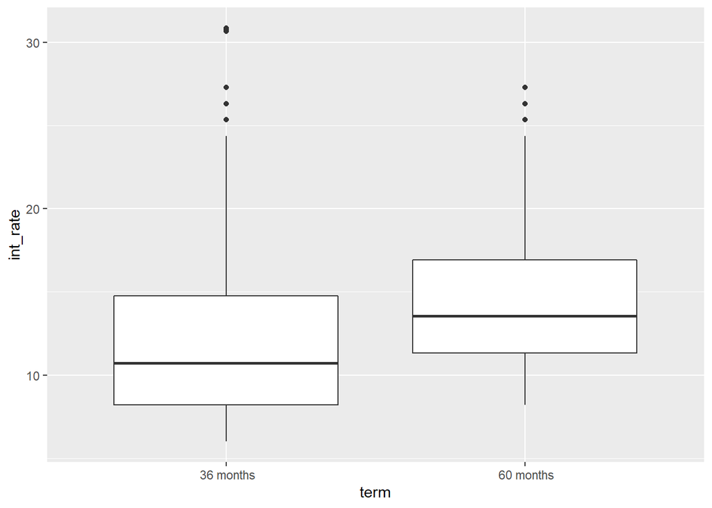

```r
ggplot(data=loans, aes(x=term, y=int_rate)) +
  geom_boxplot()
```

There seems to be a difference in average int_rate for the different term lengths. 60 month loans have an average higher interest rate.

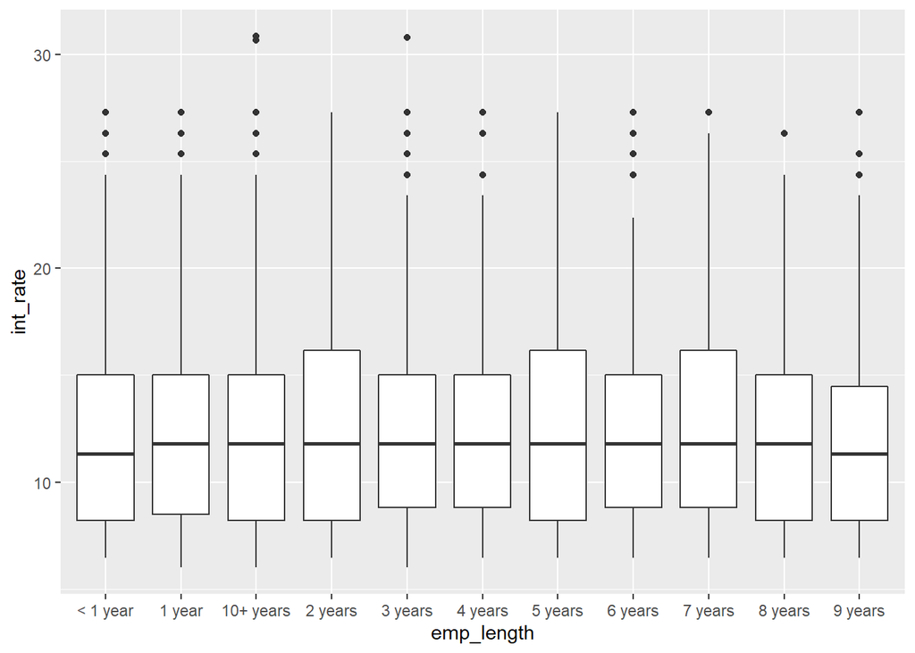

```r
ggplot(data=loans, aes(x=emp_length, y=int_rate)) +
  geom_boxplot()
```

There does not some to be any relationship between employment length and loan interest rate.

### home_ownership vs. int_rate

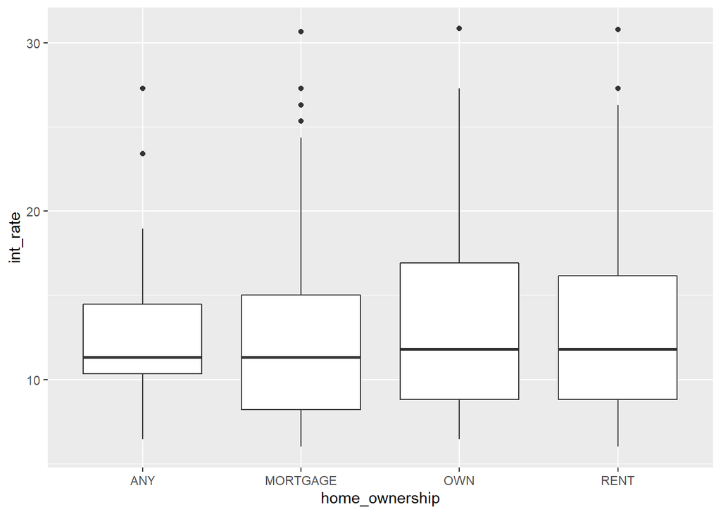

```r
ggplot(data=loans, aes(x=home_ownership, y=int_rate)) +
  geom_boxplot()
```

### annual_inc vs. int_rate

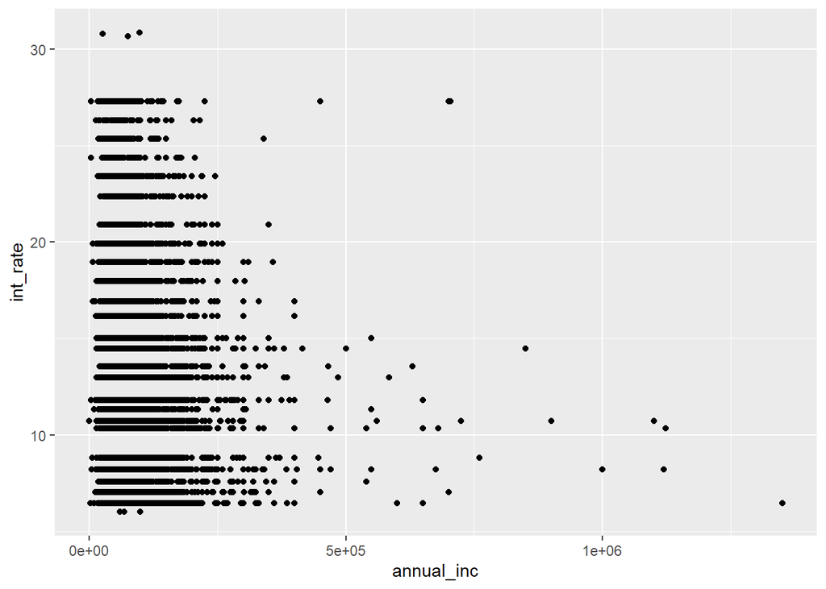

```r
ggplot(data=loans, aes(x=annual_inc, y=int_rate)) +
  geom_point()
```

From this graph, there seems to be a slight trend where higher income people get lower interest rates.

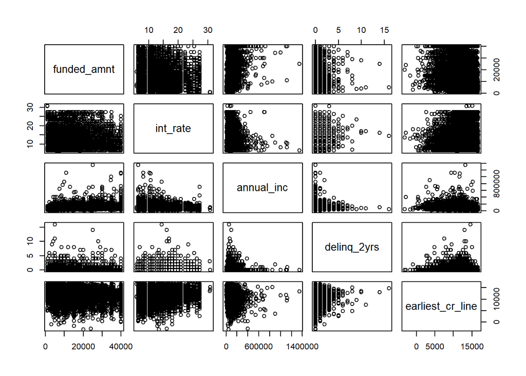

```r
plot(loans[,c(1,3,6, 9,10)])
```

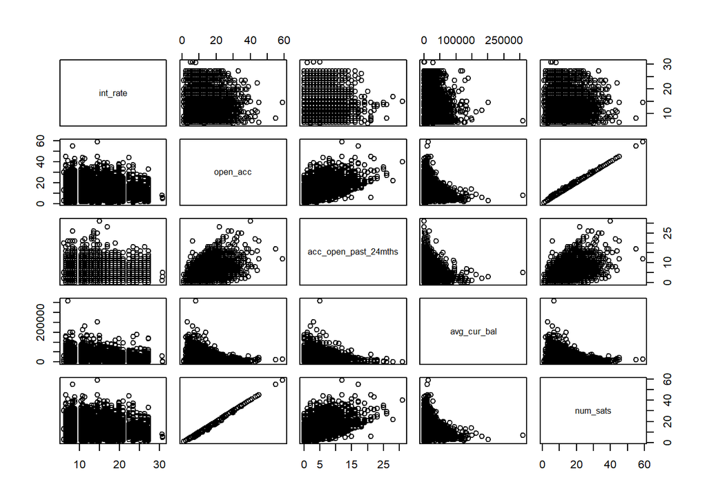

```r
plot(loans[,c(3,11, 15:17)])
```

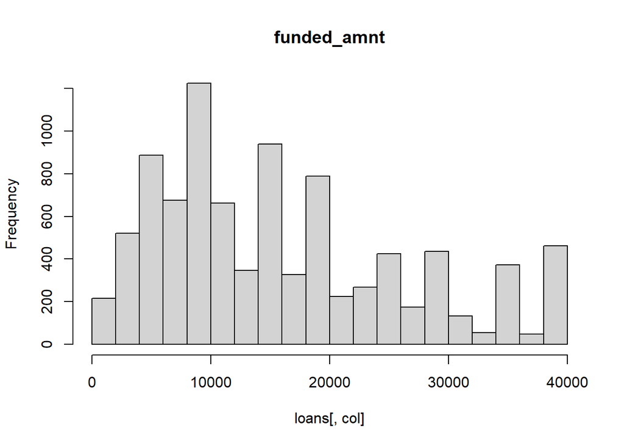

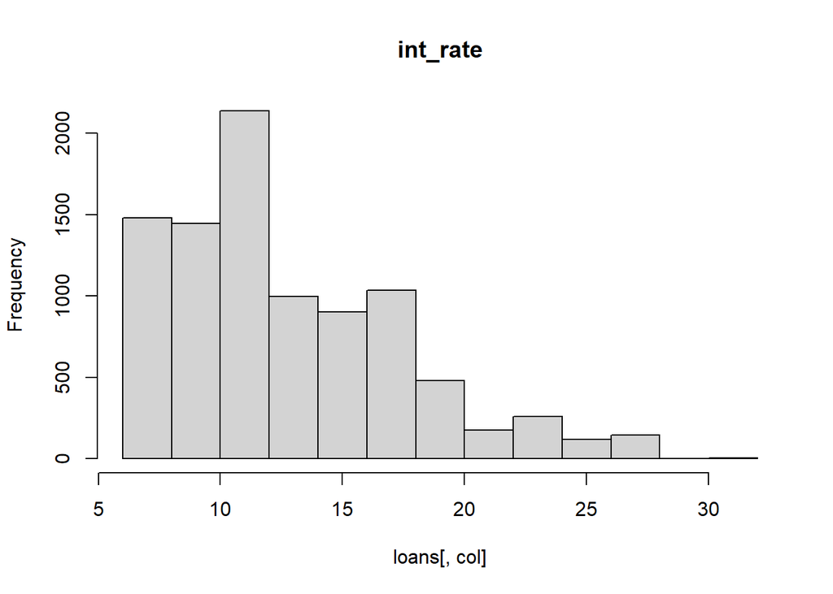

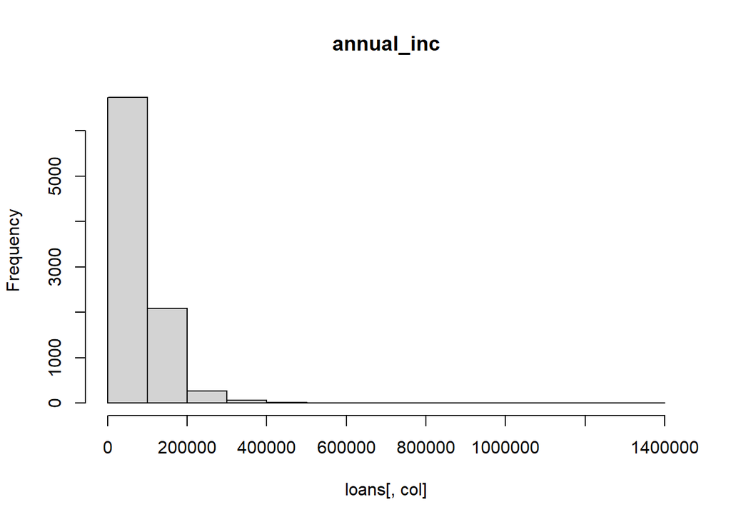

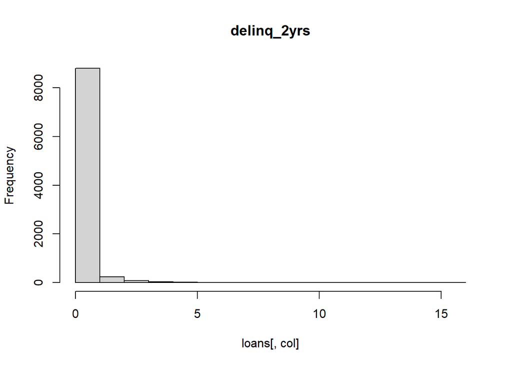

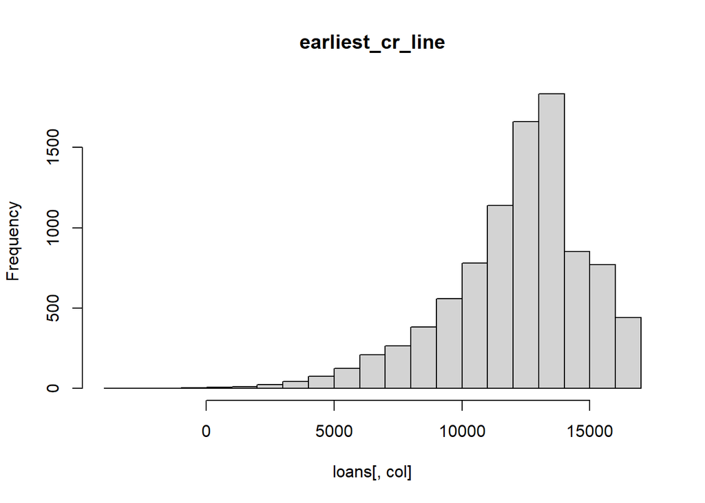

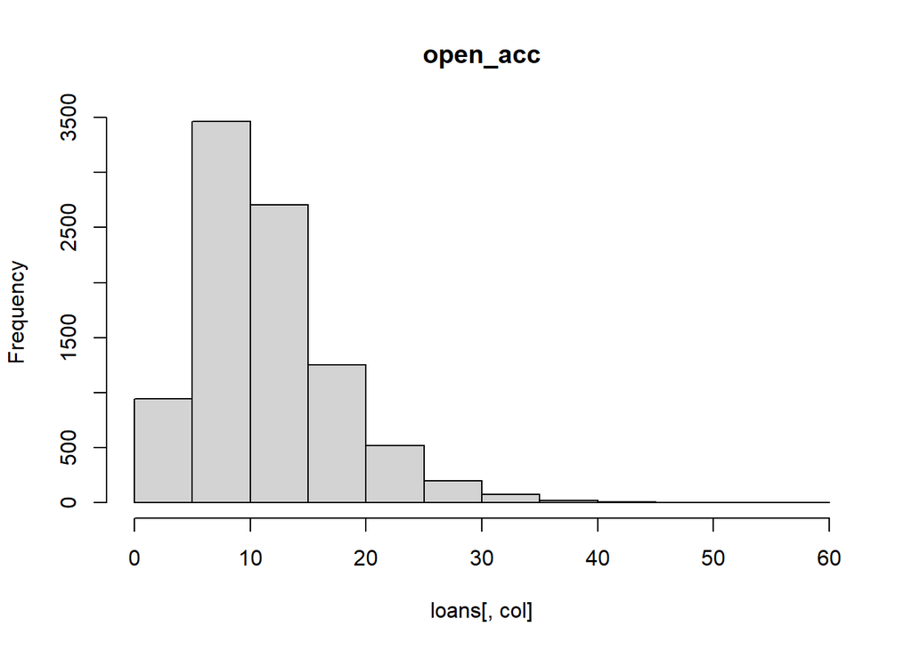

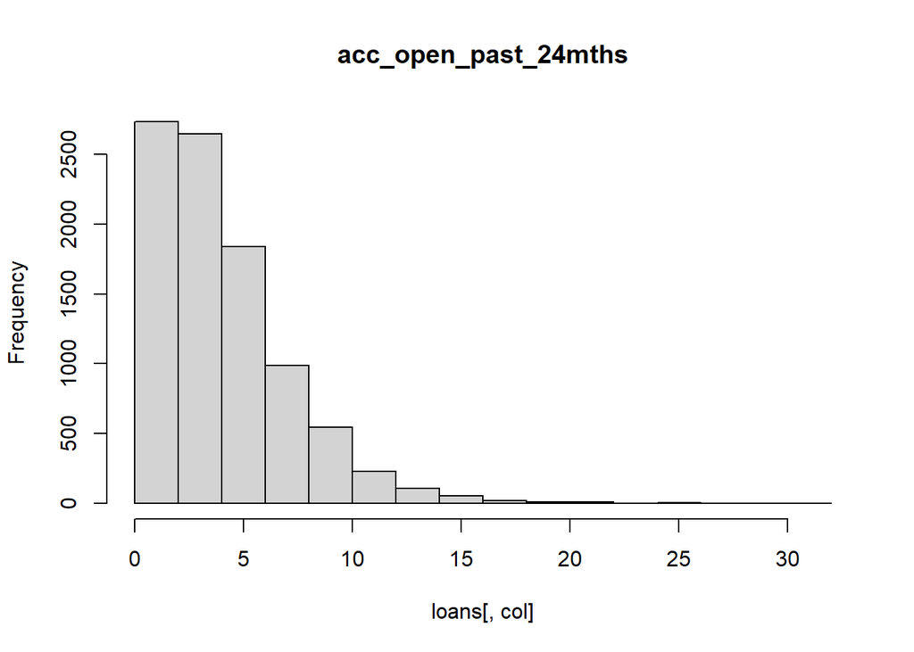

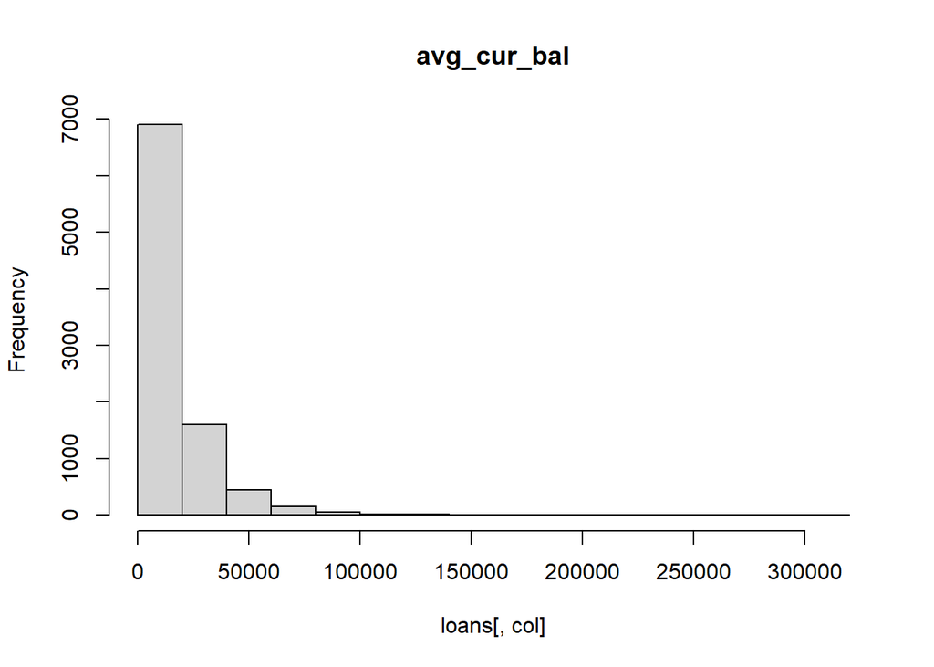

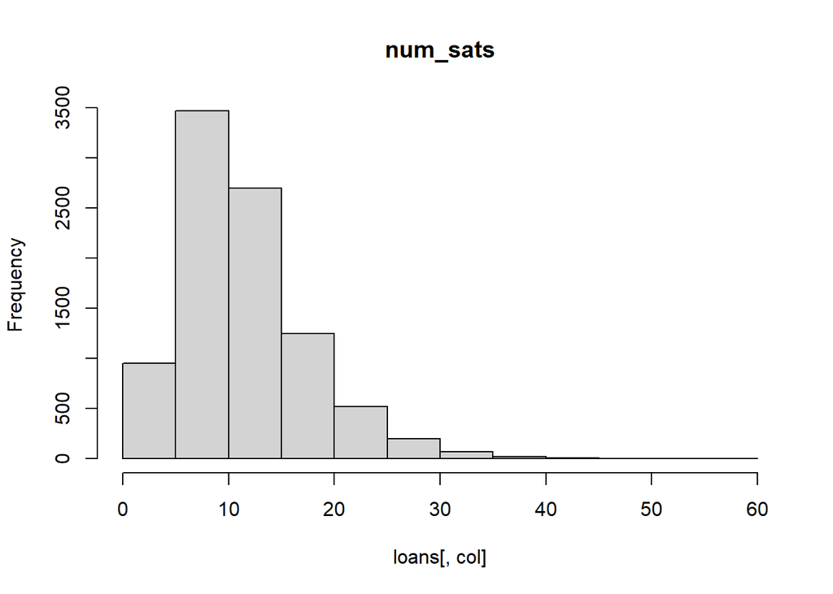

```r
for (col in c(1,3,6, 9:11, 15:17)){
  hist(loans[,col], main = names(loans[col]))
}
```

```r
for(col in c(2,4,5,7,8,12,14,18)){
  print(names(loans[col]))
  print(table(loans[,col]))
}
```

```
## [1] "term"
##
##  36 months  60 months
##       6283       2900
## [1] "emp_length"
##
##  < 1 year    1 year 10+ years   2 years   3 years   4 years   5 years   6 years
##      1268       727      2925       922       801       564       628       436
##   7 years   8 years   9 years
##       370       313       229
## [1] "home_ownership"
##
##      ANY MORTGAGE      OWN     RENT
##       17     4613      876     3677
## [1] "verification_status"
##
##    Not Verified Source Verified        Verified
##            4490            3581            1112
## [1] "purpose"
##
##                car        credit_card debt_consolidation   home_improvement
##                 91               2569               4940                497
##              house     major_purchase            medical             moving
##                 76                158                 95                 45
##              other   renewable_energy     small_business           vacation
##                533                  7                 89                 83
## [1] "pub_rec"
##
##    0    1    2    3
## 8168 1008    5    2
## [1] "initial_list_status"
##
##    f    w
## 1082 8101
## [1] "pub_rec_bankruptcies"
##
##    0    1    2    3
## 8168 1008    5    2
```

From the matrix of plots we can see that int_rate does not seem to have a non-linear relationship with any variable other that annual_inc.

# Variable Selection

For variable selection, we tested four different methods, Forwards stepwise, Backwards stepwise, Ridge regression, and LASSO. For Ridge regression and LASSO, we used cross validation in order to find the best value of $\lambda$.

```r
set.seed(2)
train = sample(nrow(loans), nrow(loans)/2)
loans_train<-loans[train,]
loans_test<-loans[-train,]
```

## Forward stepwise

```r
predict.regsubsets =function (object ,newdata ,id ,...){
form=as.formula (object$call [[2]])
mat=model.matrix (form ,newdata )
coefi =coef(object ,id=id)
xvars =names (coefi )
mat[,xvars ]%*% coefi
}

forwardm <- regsubsets(int_rate~., data = loans_train, method = "forward", nvmax = ncol(loans)-1)
val.errors <- rep(NA, ncol(loans)-1)
for (i in 1:(ncol(loans)-1)) {
    pred <- predict.regsubsets(forwardm, loans_test, i)
    val.errors[i] <- mean((loans_test$int_rate - pred)^2)
}
min(val.errors)
```

```
## [1] 19.46113
```

## Backward stepwise

```r
backwardm <- regsubsets(int_rate~., data = loans_train, method = "backward", nvmax = ncol(loans)-1)
val.errors <- rep(NA, ncol(loans)-1)
for (i in 1:(ncol(loans)-1)) {
    pred <- predict.regsubsets(backwardm, loans_test, i)
    val.errors[i] <- mean((loans_test$int_rate - pred)^2)
}

min(val.errors)
```

```
## [1] 19.53017
```

## Ridge Regression

```r
library(glmnet)

x <- model.matrix(int_rate ~ ., loans)[,-1]
y <- loans$int_rate

cv.out <- cv.glmnet(x[train,], y[train], alpha = 0)
bestlam <- cv.out$lambda.min
ridgem <- glmnet(x[train,],y[train],alpha =0, lambda =bestlam)
ridge.pred <- predict(ridgem, s = bestlam, newx = x[-train,])
mean((y[-train] - ridge.pred)^2)
```

```
## [1] 19.50978
```

## LASSO

```r
cv.out <- cv.glmnet(x[train,], y[train], alpha = 1)
bestlam <- cv.out$lambda.min
lassom <- glmnet(x[train,],y[train],alpha =1, lambda =bestlam)
lasso.pred <- predict(lassom, s = bestlam, newx = x[-train,])
mean((y[-train] - lasso.pred)^2)
```

```
## [1] 19.50922
```

Forward Stepwise ended up returning the lowest test error at about 19.46 followed by LASSO and Ridge Regression at 19.51 and the stepwise backwards at 19.53. All methods return very similar test errors, so using any method should probably be acceptable. For our own varaible reduction method, we are going to use the forwards subset selection because it returned the best test error.

```r
coef(forwardm, which.min(val.errors))
```

```
##                        (Intercept)                        funded_amnt
##                       1.241261e+01                      -5.632535e-05
##                     term 60 months             home_ownershipMORTGAGE
##                       3.076664e+00                      -9.873424e-01
##                         annual_inc verification_statusSource Verified
##                      -4.170979e-06                       1.096241e+00
##        verification_statusVerified                 purposecredit_card
##                       2.413346e+00                      -2.245862e+00
##          purposedebt_consolidation                       purposeother
##                      -8.025377e-01                       9.422172e-01
##                        delinq_2yrs                   earliest_cr_line
##                       8.013417e-01                       1.031085e-04
##                          revol_bal               initial_list_statusw
##                       7.989299e-06                      -6.703765e-01
##               acc_open_past_24mths                           num_sats
##                       2.411965e-01                      -6.320020e-02
```

Forward stepwise tells us the best model is the reduced model with the 12 variables funded_amnt, term, home_ownership, annual_inc, verification_status, purpose, delinq_2yrs, earliest_cr_line, revol_bal, initial_list_status, acc_open_past_24mths, and num_stats.

subset our data to include only variables that our variable selection method returned.

```r
loans = loans[,-c(4,11,12,16,18,19)]
#changing character data to factors
loans$home_ownership = as.factor(loans$home_ownership)
loans$term = as.factor(loans$term)
loans$verification_status = as.factor(loans$verification_status)
loans$purpose = as.factor(loans$purpose)
loans$initial_list_status = as.factor(loans$initial_list_status)
```

# Model exploration

First we create 3 training sets at sizes 500, 1000, and 4591 (half the total dataset) and their repsective test sets.

```r
set.seed(2)
trainsm = sample(nrow(loans), 500)
loans_trainsm<-loans[trainsm,]
loans_testsm<-loans[-trainsm,]

trainmed=sample(nrow(loans), 1000)
loans_trainmed<-loans[trainmed,]
loans_testmed<-loans[-trainmed,]

trainlar = sample(nrow(loans), nrow(loans)/2)
loans_trainlar<-loans[trainlar,]
loans_testlar<-loans[-trainlar,]
```

## Multiple Regression

```r
mlrsm = glm(data = loans_trainsm, int_rate~.)
mean((loans_testsm$int_rate - predict(mlrsm, loans_testsm))^2)
```

```
## [1] 19.9063
```

```r
summary(mlrsm)
```

```
##
## Call:
## glm(formula = int_rate ~ ., data = loans_trainsm)
##
## Deviance Residuals:
##    Min      1Q  Median      3Q     Max
## -8.523  -2.791  -0.850   2.010  16.128
##
## Coefficients:
##                                      Estimate Std. Error t value Pr(>|t|)
## (Intercept)                         1.317e+01  3.498e+00   3.765 0.000187 ***
## funded_amnt                        -6.153e-05  2.226e-05  -2.763 0.005943 **
## term 60 months                      2.892e+00  4.701e-01   6.152 1.63e-09 ***
## home_ownershipMORTGAGE             -6.812e+00  3.018e+00  -2.257 0.024451 *
## home_ownershipOWN                  -5.603e+00  3.060e+00  -1.831 0.067724 .
## home_ownershipRENT                 -5.923e+00  3.018e+00  -1.963 0.050288 .
## annual_inc                         -3.833e-07  3.596e-06  -0.107 0.915148
## verification_statusSource Verified  1.240e+00  4.170e-01   2.974 0.003092 **
## verification_statusVerified         1.990e+00  7.080e-01   2.811 0.005148 **
## purposecredit_card                  6.627e-01  1.467e+00   0.452 0.651707
## purposedebt_consolidation           1.639e+00  1.437e+00   1.141 0.254440
## purposehome_improvement             1.716e+00  1.641e+00   1.046 0.296260
## purposehouse                        5.612e+00  2.181e+00   2.574 0.010370 *
## purposemajor_purchase               4.276e+00  2.020e+00   2.117 0.034752 *
## purposemedical                      2.659e+00  2.011e+00   1.322 0.186758
## purposemoving                       3.120e+00  2.260e+00   1.381 0.168019
## purposeother                        3.270e+00  1.635e+00   2.001 0.046012 *
## purposerenewable_energy            -3.148e+00  4.475e+00  -0.703 0.482138
## purposesmall_business               7.045e+00  4.543e+00   1.551 0.121624
## purposevacation                     7.217e+00  2.840e+00   2.541 0.011374 *
## delinq_2yrs                         5.218e-01  3.494e-01   1.494 0.135944
## earliest_cr_line                    1.415e-04  7.429e-05   1.905 0.057364 .
## revol_bal                           2.717e-06  8.027e-06   0.338 0.735163
## initial_list_statusw                6.202e-01  6.144e-01   1.009 0.313282
## acc_open_past_24mths                2.477e-01  7.580e-02   3.268 0.001162 **
## num_sats                           -2.612e-02  3.796e-02  -0.688 0.491784
## ---
## Signif. codes:  0 '***' 0.001 '**' 0.01 '*' 0.05 '.' 0.1 ' ' 1
##
## (Dispersion parameter for gaussian family taken to be 17.72353)
##
##     Null deviance: 10326  on 499  degrees of freedom
## Residual deviance:  8401  on 474  degrees of freedom
## AIC: 2883.7
##
## Number of Fisher Scoring iterations: 2
```

```r
mlrmed = glm(data = loans_trainmed, int_rate~.)
mean((loans_testmed$int_rate - predict(mlrmed, loans_testmed))^2)
```

```
## [1] 19.27688
```

```r
summary(mlrmed)
```

```
##
## Call:
## glm(formula = int_rate ~ ., data = loans_trainmed)
##
## Deviance Residuals:
##     Min       1Q   Median       3Q      Max
## -8.2446  -3.1412  -0.8335   2.4783  16.4616
##
## Coefficients:
##                                      Estimate Std. Error t value Pr(>|t|)
## (Intercept)                         1.499e+01  2.716e+00   5.520 4.36e-08 ***
## funded_amnt                        -3.325e-05  1.641e-05  -2.026 0.043062 *
## term 60 months                      2.669e+00  3.295e-01   8.100 1.63e-15 ***
## home_ownershipMORTGAGE             -6.064e+00  2.217e+00  -2.735 0.006343 **
## home_ownershipOWN                  -4.743e+00  2.255e+00  -2.103 0.035680 *
## home_ownershipRENT                 -5.078e+00  2.211e+00  -2.296 0.021871 *
## annual_inc                         -8.474e-06  3.124e-06  -2.712 0.006798 **
## verification_statusSource Verified  9.980e-01  3.023e-01   3.302 0.000996 ***
## verification_statusVerified         2.481e+00  4.741e-01   5.234 2.04e-07 ***
## purposecredit_card                 -3.188e-01  1.351e+00  -0.236 0.813504
## purposedebt_consolidation           1.319e+00  1.340e+00   0.984 0.325444
## purposehome_improvement             3.246e+00  1.467e+00   2.212 0.027167 *
## purposehouse                        2.016e+00  2.382e+00   0.846 0.397510
## purposemajor_purchase               2.667e+00  1.653e+00   1.613 0.106961
## purposemedical                      2.251e+00  1.803e+00   1.249 0.212046
## purposemoving                       2.484e+00  2.378e+00   1.045 0.296451
## purposeother                        4.114e+00  1.446e+00   2.846 0.004525 **
## purposerenewable_energy             3.335e+00  2.858e+00   1.167 0.243655
## purposesmall_business               1.990e+00  1.779e+00   1.119 0.263529
## purposevacation                     1.894e+00  1.929e+00   0.982 0.326576
## delinq_2yrs                         9.826e-01  1.868e-01   5.260 1.77e-07 ***
## earliest_cr_line                    1.267e-04  5.823e-05   2.177 0.029737 *
## revol_bal                           1.422e-05  7.548e-06   1.884 0.059819 .
## initial_list_statusw               -5.836e-01  4.381e-01  -1.332 0.183061
## acc_open_past_24mths                2.652e-01  5.610e-02   4.727 2.61e-06 ***
## num_sats                           -5.671e-02  2.805e-02  -2.021 0.043504 *
## ---
## Signif. codes:  0 '***' 0.001 '**' 0.01 '*' 0.05 '.' 0.1 ' ' 1
##
## (Dispersion parameter for gaussian family taken to be 19.18558)
##
##     Null deviance: 23677  on 999  degrees of freedom
## Residual deviance: 18687  on 974  degrees of freedom
## AIC: 5819.7
##
## Number of Fisher Scoring iterations: 2
```

```r
mlrlar = glm(data = loans_trainlar, int_rate~.)
mean((loans_testlar$int_rate - predict(mlrlar, loans_testlar))^2)
```

```
## [1] 19.46225
```

```r
summary(mlrlar)
```

```
##
## Call:
## glm(formula = int_rate ~ ., data = loans_trainlar)
##
## Deviance Residuals:
##      Min        1Q    Median        3Q       Max
## -12.3129   -3.0725   -0.8161    2.2750   16.7136
##
## Coefficients:
##                                      Estimate Std. Error t value Pr(>|t|)
## (Intercept)                         1.373e+01  1.488e+00   9.228  < 2e-16 ***
## funded_amnt                        -5.754e-05  7.506e-06  -7.666 2.15e-14 ***
## term 60 months                      3.146e+00  1.499e-01  20.986  < 2e-16 ***
## home_ownershipMORTGAGE             -3.862e+00  1.297e+00  -2.977  0.00293 **
## home_ownershipOWN                  -2.933e+00  1.308e+00  -2.242  0.02501 *
## home_ownershipRENT                 -2.792e+00  1.296e+00  -2.155  0.03121 *
## annual_inc                         -4.918e-06  1.149e-06  -4.279 1.92e-05 ***
## verification_statusSource Verified  9.995e-01  1.381e-01   7.238 5.32e-13 ***
## verification_statusVerified         2.017e+00  2.106e-01   9.574  < 2e-16 ***
## purposecredit_card                 -8.556e-01  6.178e-01  -1.385  0.16616
## purposedebt_consolidation           6.285e-01  6.134e-01   1.025  0.30558
## purposehome_improvement             9.968e-01  6.675e-01   1.493  0.13540
## purposehouse                        3.578e+00  9.174e-01   3.900 9.75e-05 ***
## purposemajor_purchase               1.344e+00  7.773e-01   1.729  0.08395 .
## purposemedical                      8.757e-01  8.858e-01   0.989  0.32291
## purposemoving                       3.728e-01  1.116e+00   0.334  0.73844
## purposeother                        2.636e+00  6.617e-01   3.984 6.88e-05 ***
## purposerenewable_energy             2.836e+00  2.007e+00   1.413  0.15777
## purposesmall_business               1.947e+00  9.112e-01   2.136  0.03270 *
## purposevacation                     2.682e+00  9.383e-01   2.859  0.00427 **
## delinq_2yrs                         7.526e-01  8.487e-02   8.867  < 2e-16 ***
## earliest_cr_line                    1.165e-04  2.534e-05   4.598 4.39e-06 ***
## revol_bal                           1.530e-05  3.297e-06   4.642 3.55e-06 ***
## initial_list_statusw               -6.455e-01  2.013e-01  -3.207  0.00135 **
## acc_open_past_24mths                2.499e-01  2.337e-02  10.691  < 2e-16 ***
## num_sats                           -6.794e-02  1.282e-02  -5.298 1.22e-07 ***
## ---
## Signif. codes:  0 '***' 0.001 '**' 0.01 '*' 0.05 '.' 0.1 ' ' 1
##
## (Dispersion parameter for gaussian family taken to be 18.28902)
##
##     Null deviance: 104670  on 4590  degrees of freedom
## Residual deviance:  83489  on 4565  degrees of freedom
## AIC: 26399
##
## Number of Fisher Scoring iterations: 2
```

## Polynomial Regression

```r
poly_degrees = c(2,3,5,10)
cv.error = rep(0,4)
for (i in 1:4){
  glm.fit = glm(data = loans, int_rate~poly(funded_amnt, poly_degrees[i])+ poly(annual_inc,poly_degrees[i])+poly(delinq_2yrs, poly_degrees[i]) + poly(earliest_cr_line, poly_degrees[i])+ poly(revol_bal, poly_degrees[i])+ poly(acc_open_past_24mths, poly_degrees[i])+poly(num_sats, poly_degrees[i]) + term + home_ownership + verification_status+purpose+initial_list_status)
  cv.error[i] = cv.glm(loans, glmfit = glm.fit, K=5)$delta[1]
}
cv.error
```

```
## [1] 1.867778e+01 1.865014e+01 1.672858e+02 2.247522e+42
```

```r
#Minimum is polynomial of degree 3
plm.fitsm= glm(data = loans_trainsm, int_rate~poly(funded_amnt, 3)+ poly(annual_inc,3)+poly(delinq_2yrs, 3) + poly(earliest_cr_line, 3)+ poly(revol_bal, 3)+ poly(acc_open_past_24mths, 3)+poly(num_sats, 3) + term + home_ownership + verification_status+purpose+initial_list_status)

plm.fitmed = glm(data = loans_trainmed, int_rate~poly(funded_amnt, 3)+ poly(annual_inc,3)+poly(delinq_2yrs, 3) + poly(earliest_cr_line, 3)+ poly(revol_bal, 3)+ poly(acc_open_past_24mths, 3)+poly(num_sats, 3) + term + home_ownership + verification_status+purpose+initial_list_status)

plm.fitlar = glm(data = loans_trainlar, int_rate~poly(funded_amnt, 3)+ poly(annual_inc,3)+poly(delinq_2yrs, 3) + poly(earliest_cr_line, 3)+ poly(revol_bal, 3)+ poly(acc_open_past_24mths, 3)+poly(num_sats, 3) + term + home_ownership + verification_status+purpose+initial_list_status)


mean((loans_testsm$int_rate - predict(plm.fitsm, loans_testsm))^2)
```

```
## [1] 180.9185
```

```r
summary(plm.fitsm)
```

```
##
## Call:
## glm(formula = int_rate ~ poly(funded_amnt, 3) + poly(annual_inc,
##     3) + poly(delinq_2yrs, 3) + poly(earliest_cr_line, 3) + poly(revol_bal,
##     3) + poly(acc_open_past_24mths, 3) + poly(num_sats, 3) +
##     term + home_ownership + verification_status + purpose + initial_list_status,
##     data = loans_trainsm)
##
## Deviance Residuals:
##     Min       1Q   Median       3Q      Max
## -8.0884  -2.8091  -0.5867   2.2853  15.4510
##
## Coefficients:
##                                    Estimate Std. Error t value Pr(>|t|)
## (Intercept)                         16.5184     3.3770   4.891 1.39e-06 ***
## poly(funded_amnt, 3)1              -17.6945     5.7457  -3.080 0.002197 **
## poly(funded_amnt, 3)2                6.9827     4.4463   1.570 0.116997
## poly(funded_amnt, 3)3              -14.7816     4.3433  -3.403 0.000724 ***
## poly(annual_inc, 3)1                -1.5417     5.3970  -0.286 0.775272
## poly(annual_inc, 3)2                 6.5150     5.1167   1.273 0.203560
## poly(annual_inc, 3)3                -0.2948     4.5798  -0.064 0.948698
## poly(delinq_2yrs, 3)1                8.8669     4.3208   2.052 0.040720 *
## poly(delinq_2yrs, 3)2                6.5829     4.2682   1.542 0.123686
## poly(delinq_2yrs, 3)3                6.4282     4.2331   1.519 0.129557
## poly(earliest_cr_line, 3)1          10.1354     4.6786   2.166 0.030800 *
## poly(earliest_cr_line, 3)2           7.0071     4.3490   1.611 0.107826
## poly(earliest_cr_line, 3)3           5.7483     4.2979   1.337 0.181735
## poly(revol_bal, 3)1                  4.2631     5.3212   0.801 0.423453
## poly(revol_bal, 3)2                -19.9108     5.0872  -3.914 0.000105 ***
## poly(revol_bal, 3)3                  3.8583     4.5886   0.841 0.400863
## poly(acc_open_past_24mths, 3)1      22.8894     5.3541   4.275 2.32e-05 ***
## poly(acc_open_past_24mths, 3)2      -7.2082     4.3967  -1.639 0.101805
## poly(acc_open_past_24mths, 3)3      -1.5314     4.3580  -0.351 0.725449
## poly(num_sats, 3)1                  -9.9385     5.5318  -1.797 0.073052 .
## poly(num_sats, 3)2                   2.2422     4.5101   0.497 0.619325
## poly(num_sats, 3)3                   1.5286     4.3491   0.351 0.725389
## term 60 months                       3.0991     0.4717   6.570 1.36e-10 ***
## home_ownershipMORTGAGE              -7.9029     2.9794  -2.653 0.008265 **
## home_ownershipOWN                   -6.7271     3.0091  -2.236 0.025857 *
## home_ownershipRENT                  -7.0287     2.9756  -2.362 0.018585 *
```

[output cut: 9 more lines]

```
## purposeother                         2.4113     1.6234   1.485 0.138136
## purposerenewable_energy             -4.0182     4.3840  -0.917 0.359855
## purposesmall_business                4.8709     4.4639   1.091 0.275763
## purposevacation                      6.2353     2.7846   2.239 0.025618 *
## initial_list_statusw                 0.9813     0.6138   1.599 0.110559
## ---
## Signif. codes:  0 '***' 0.001 '**' 0.01 '*' 0.05 '.' 0.1 ' ' 1
##
## (Dispersion parameter for gaussian family taken to be 16.81777)
##
##     Null deviance: 10326.0  on 499  degrees of freedom
## Residual deviance:  7736.2  on 460  degrees of freedom
## AIC: 2870.5
##
## Number of Fisher Scoring iterations: 2
```

```r
mean((loans_testmed$int_rate - predict(plm.fitmed, loans_testmed))^2)
```

```
## [1] 250.8206
```

```r
summary(plm.fitmed)
```

```
##
## Call:
## glm(formula = int_rate ~ poly(funded_amnt, 3) + poly(annual_inc,
##     3) + poly(delinq_2yrs, 3) + poly(earliest_cr_line, 3) + poly(revol_bal,
##     3) + poly(acc_open_past_24mths, 3) + poly(num_sats, 3) +
##     term + home_ownership + verification_status + purpose + initial_list_status,
##     data = loans_trainmed)
##
## Deviance Residuals:
##     Min       1Q   Median       3Q      Max
## -9.2244  -3.0044  -0.7052   2.2884  16.4647
##
## Coefficients:
##                                    Estimate Std. Error t value Pr(>|t|)
## (Intercept)                         16.1048     2.5881   6.223 7.29e-10 ***
## poly(funded_amnt, 3)1              -13.5218     5.8088  -2.328  0.02013 *
## poly(funded_amnt, 3)2               -4.9596     4.6296  -1.071  0.28432
## poly(funded_amnt, 3)3              -10.9829     4.5142  -2.433  0.01516 *
## poly(annual_inc, 3)1               -19.4286     6.5080  -2.985  0.00290 **
## poly(annual_inc, 3)2                -1.5117     7.7122  -0.196  0.84464
## poly(annual_inc, 3)3               -15.1230     6.3766  -2.372  0.01791 *
## poly(delinq_2yrs, 3)1               25.9507     4.4915   5.778 1.02e-08 ***
## poly(delinq_2yrs, 3)2              -13.7446     4.4524  -3.087  0.00208 **
## poly(delinq_2yrs, 3)3                1.7177     4.4180   0.389  0.69752
## poly(earliest_cr_line, 3)1          11.6014     4.9089   2.363  0.01831 *
## poly(earliest_cr_line, 3)2           0.2242     4.5678   0.049  0.96087
## poly(earliest_cr_line, 3)3           0.2163     4.4092   0.049  0.96088
## poly(revol_bal, 3)1                 18.4092     7.1062   2.591  0.00973 **
## poly(revol_bal, 3)2                 -6.8324     7.5523  -0.905  0.36586
## poly(revol_bal, 3)3                 13.9506     6.2110   2.246  0.02492 *
## poly(acc_open_past_24mths, 3)1      30.5210     5.3327   5.723 1.40e-08 ***
## poly(acc_open_past_24mths, 3)2      -5.6207     4.6596  -1.206  0.22800
## poly(acc_open_past_24mths, 3)3       7.8293     4.6029   1.701  0.08928 .
## poly(num_sats, 3)1                 -17.8463     5.6638  -3.151  0.00168 **
## poly(num_sats, 3)2                   0.1211     4.7816   0.025  0.97981
## poly(num_sats, 3)3                 -11.8824     4.6415  -2.560  0.01062 *
## term 60 months                       2.7204     0.3340   8.145 1.17e-15 ***
## home_ownershipMORTGAGE              -6.1290     2.1945  -2.793  0.00533 **
## home_ownershipOWN                   -4.7617     2.2319  -2.133  0.03314 *
## home_ownershipRENT                  -5.0376     2.1884  -2.302  0.02155 *
```

[output cut: 9 more lines]

```
## purposeother                         4.2582     1.4344   2.969  0.00306 **
## purposerenewable_energy              3.3999     2.8240   1.204  0.22892
## purposesmall_business                2.0865     1.7631   1.183  0.23693
## purposevacation                      1.8529     1.9203   0.965  0.33483
## initial_list_statusw                -0.4694     0.4457  -1.053  0.29246
## ---
## Signif. codes:  0 '***' 0.001 '**' 0.01 '*' 0.05 '.' 0.1 ' ' 1
##
## (Dispersion parameter for gaussian family taken to be 18.68194)
##
##     Null deviance: 23677  on 999  degrees of freedom
## Residual deviance: 17935  on 960  degrees of freedom
## AIC: 5806.6
##
## Number of Fisher Scoring iterations: 2
```

```r
mean((loans_testlar$int_rate - predict(plm.fitlar, loans_testlar))^2)
```

```
## [1] 71.39273
```

```r
summary(plm.fitlar)
```

```
##
## Call:
## glm(formula = int_rate ~ poly(funded_amnt, 3) + poly(annual_inc,
##     3) + poly(delinq_2yrs, 3) + poly(earliest_cr_line, 3) + poly(revol_bal,
##     3) + poly(acc_open_past_24mths, 3) + poly(num_sats, 3) +
##     term + home_ownership + verification_status + purpose + initial_list_status,
##     data = loans_trainlar)
##
## Deviance Residuals:
##      Min        1Q    Median        3Q       Max
## -10.2874   -2.9972   -0.7427    2.2235   16.7136
##
## Coefficients:
##                                    Estimate Std. Error t value Pr(>|t|)
## (Intercept)                         14.0080     1.4207   9.860  < 2e-16 ***
## poly(funded_amnt, 3)1              -40.7875     5.5764  -7.314 3.04e-13 ***
## poly(funded_amnt, 3)2               -7.6869     4.4704  -1.720 0.085590 .
## poly(funded_amnt, 3)3              -26.2854     4.3004  -6.112 1.06e-09 ***
## poly(annual_inc, 3)1               -26.6100     5.0531  -5.266 1.46e-07 ***
## poly(annual_inc, 3)2                13.8261     4.5136   3.063 0.002203 **
## poly(annual_inc, 3)3               -15.1251     4.4529  -3.397 0.000688 ***
## poly(delinq_2yrs, 3)1               44.4546     4.3306  10.265  < 2e-16 ***
## poly(delinq_2yrs, 3)2              -21.0975     4.2412  -4.974 6.79e-07 ***
## poly(delinq_2yrs, 3)3                5.8699     4.2272   1.389 0.165022
## poly(earliest_cr_line, 3)1          23.7508     4.6377   5.121 3.16e-07 ***
## poly(earliest_cr_line, 3)2           6.3622     4.3278   1.470 0.141611
## poly(earliest_cr_line, 3)3          -3.3673     4.2369  -0.795 0.426806
## poly(revol_bal, 3)1                 31.4842     5.1624   6.099 1.16e-09 ***
## poly(revol_bal, 3)2                -31.4639     4.7676  -6.600 4.60e-11 ***
## poly(revol_bal, 3)3                 12.1141     4.4276   2.736 0.006243 **
## poly(acc_open_past_24mths, 3)1      65.1177     5.1789  12.574  < 2e-16 ***
## poly(acc_open_past_24mths, 3)2     -26.5084     4.4427  -5.967 2.60e-09 ***
## poly(acc_open_past_24mths, 3)3       6.5606     4.3139   1.521 0.128384
## poly(num_sats, 3)1                 -40.8503     5.5163  -7.405 1.55e-13 ***
## poly(num_sats, 3)2                  20.8374     4.5008   4.630 3.76e-06 ***
## poly(num_sats, 3)3                  -5.1708     4.3159  -1.198 0.230956
## term 60 months                       3.1235     0.1516  20.604  < 2e-16 ***
## home_ownershipMORTGAGE              -3.4115     1.2777  -2.670 0.007611 **
## home_ownershipOWN                   -2.5637     1.2881  -1.990 0.046616 *
## home_ownershipRENT                  -2.3302     1.2757  -1.827 0.067828 .
```

[output cut: 9 more lines]

```
## purposeother                         2.6590     0.6523   4.077 4.65e-05 ***
## purposerenewable_energy              2.7675     1.9757   1.401 0.161356
## purposesmall_business                2.3073     0.8979   2.570 0.010214 *
## purposevacation                      2.6817     0.9290   2.887 0.003911 **
## initial_list_statusw                -0.4925     0.2011  -2.449 0.014355 *
## ---
## Signif. codes:  0 '***' 0.001 '**' 0.01 '*' 0.05 '.' 0.1 ' ' 1
##
## (Dispersion parameter for gaussian family taken to be 17.69662)
##
##     Null deviance: 104670  on 4590  degrees of freedom
## Residual deviance:  80537  on 4551  degrees of freedom
## AIC: 26262
##
## Number of Fisher Scoring iterations: 2
```

## Regression Tree

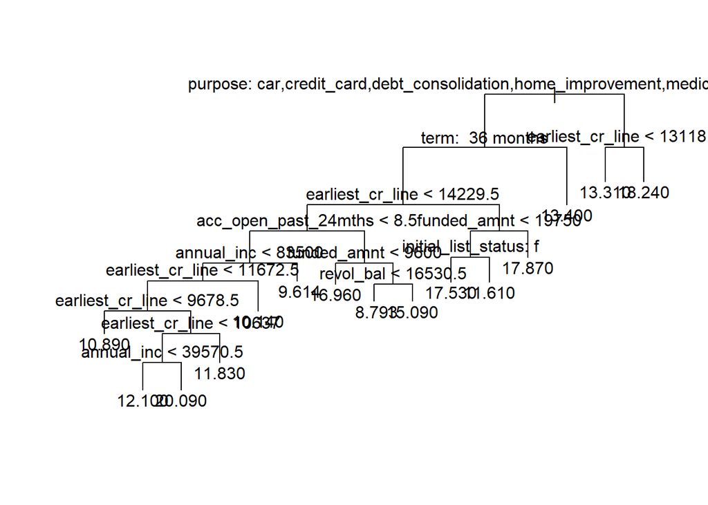

```r
treesm = tree(int_rate~., data = loans_trainsm)
plot(treesm)
text(treesm, pretty=0)
```

```r
preds = predict(treesm, newdata = loans_testsm)
mean((loans_testsm$int_rate - preds)^2)
```

```
## [1] 24.89839
```

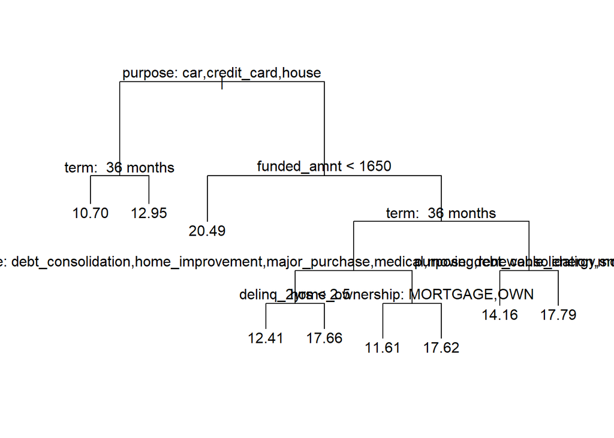

```r
treemed = tree(int_rate~., data = loans_trainmed)
plot(treemed)
text(treemed, pretty=0)
```

```r
preds = predict(treemed, newdata = loans_testmed)
mean((loans_testmed$int_rate - preds)^2)
```

```
## [1] 21.43477
```

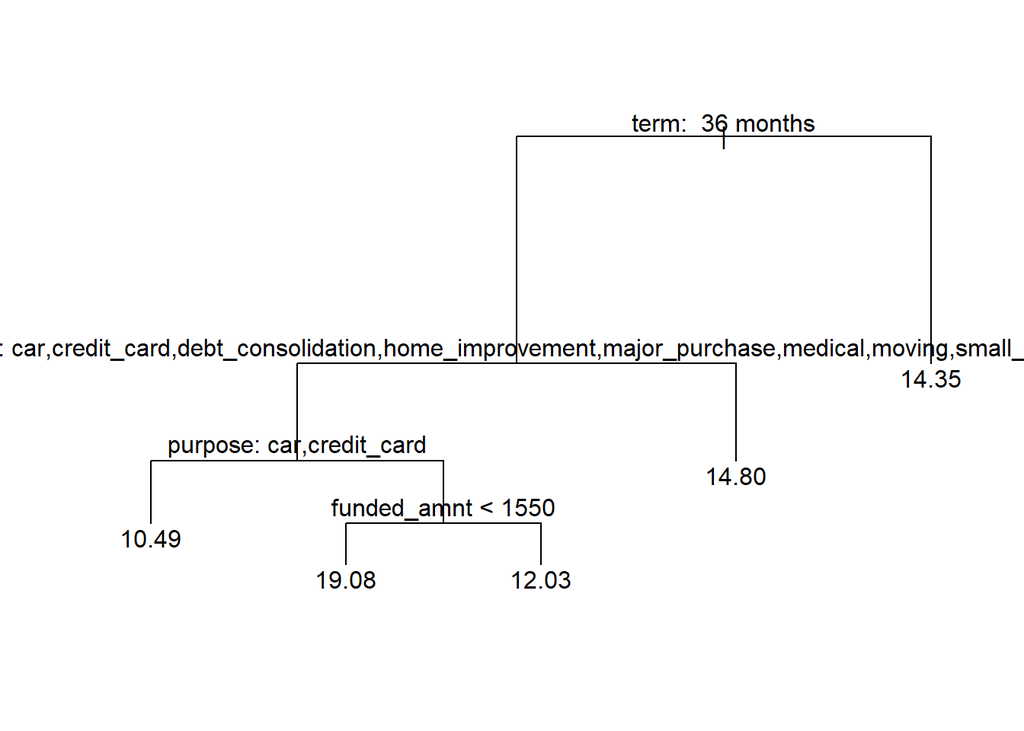

```r
treelar = tree(int_rate~., data = loans_trainlar)
plot(treelar)
text(treelar, pretty=0)
```

```r
preds = predict(treelar, newdata = loans_testlar)
mean((loans_testlar$int_rate - preds)^2)
```

```
## [1] 21.60858
```

Before cross-validation, the largest training data performs the best, closely followed by the medium, and then the smallest is well behind. Overall, these models have around 2 units more test error than previous models.

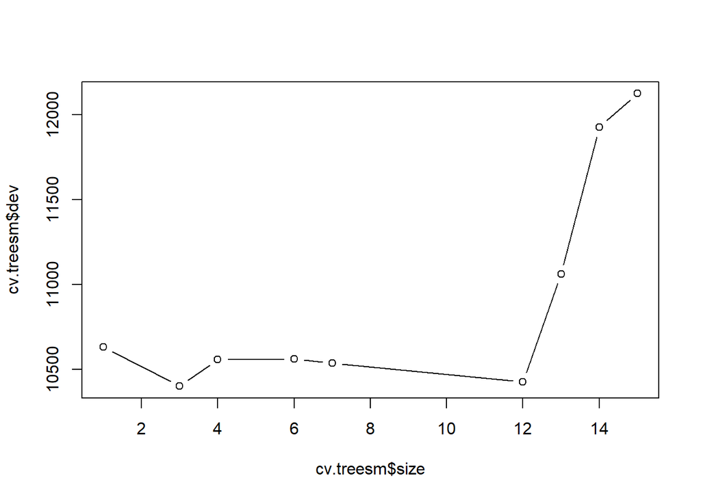

```r
set.seed(1)
cv.treesm = cv.tree(treesm)
plot(cv.treesm$size, cv.treesm$dev, type = 'b')
```

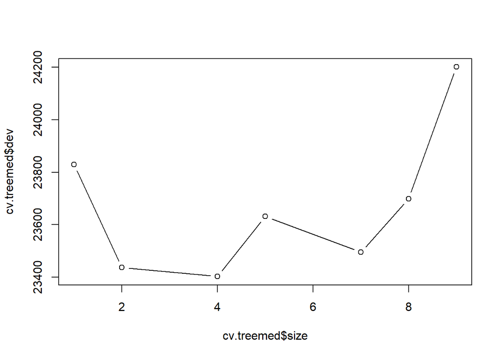

```r
cv.treemed = cv.tree(treemed)
plot(cv.treemed$size, cv.treemed$dev, type = 'b')
```

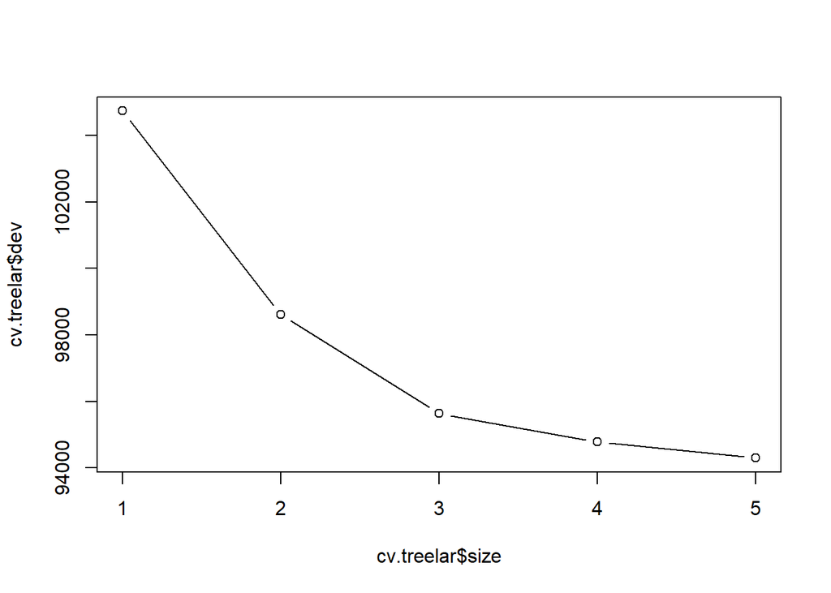

```r
cv.treelar = cv.tree(treelar)
plot(cv.treelar$size, cv.treelar$dev, type = 'b')
```

The optimal number of splits for the largest training data is five, for the small 3, and for the medium 4.

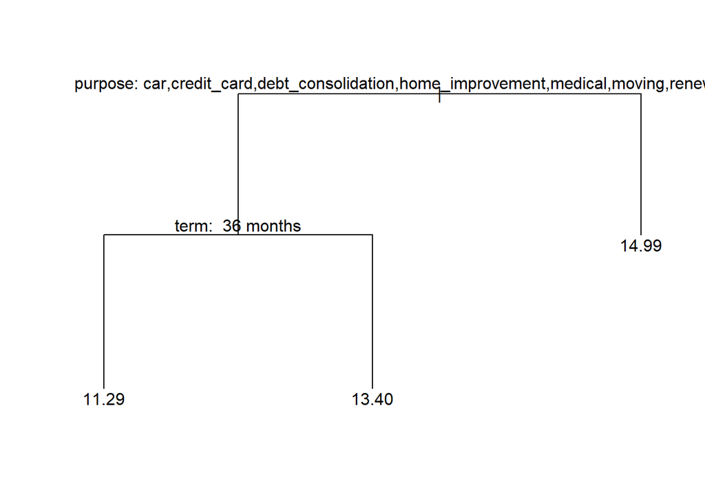

```r
#the largest is just the full model.

prune.treesm = prune.tree(treesm, best = 3)
plot(prune.treesm)
text(prune.treesm, pretty=0)
```

```r
preds = predict(prune.treesm, newdata = loans_testsm)
mean((loans_testsm$int_rate - preds)^2)
```

```
## [1] 21.64741
```

```r
summary(prune.treesm)
```

```
##
## Regression tree:
## snip.tree(tree = treesm, nodes = 4:3)
## Variables actually used in tree construction:
## [1] "purpose" "term"
## Number of terminal nodes:  3
## Residual mean deviance:  19.11 = 9499 / 497
## Distribution of residuals:
##    Min. 1st Qu.  Median    Mean 3rd Qu.    Max.
## -8.5270 -3.0980 -0.5682  0.0000  2.7400 15.0200
```

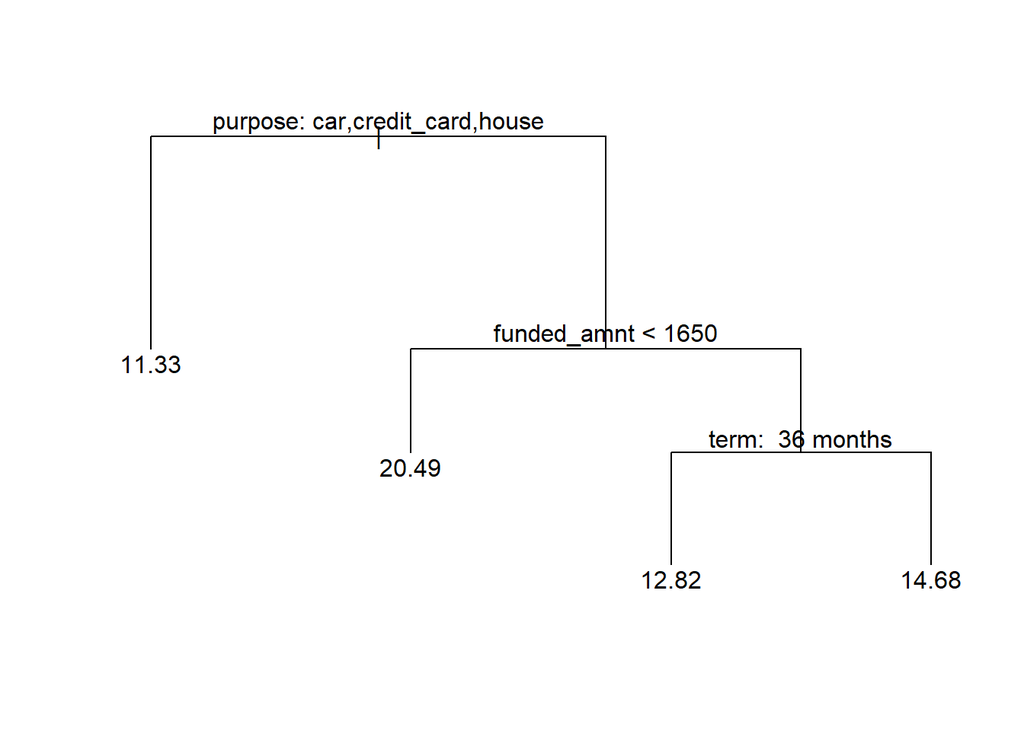

```r
prune.treemed = prune.tree(treemed, best = 4)

plot(prune.treemed)
text(prune.treemed, pretty=0)
```

```r
preds = predict(prune.treemed, newdata = loans_testmed)
mean((loans_testmed$int_rate - preds)^2)
```

```
## [1] 21.70121
```

```r
summary(prune.treemed)
```

```
##
## Regression tree:
## snip.tree(tree = treemed, nodes = c(2L, 14L, 15L))
## Variables actually used in tree construction:
## [1] "purpose"     "funded_amnt" "term"
## Number of terminal nodes:  4
## Residual mean deviance:  21.73 = 21650 / 996
## Distribution of residuals:
##    Min. 1st Qu.  Median    Mean 3rd Qu.    Max.
##  -6.933  -3.956  -1.002   0.000   2.965  15.940
```

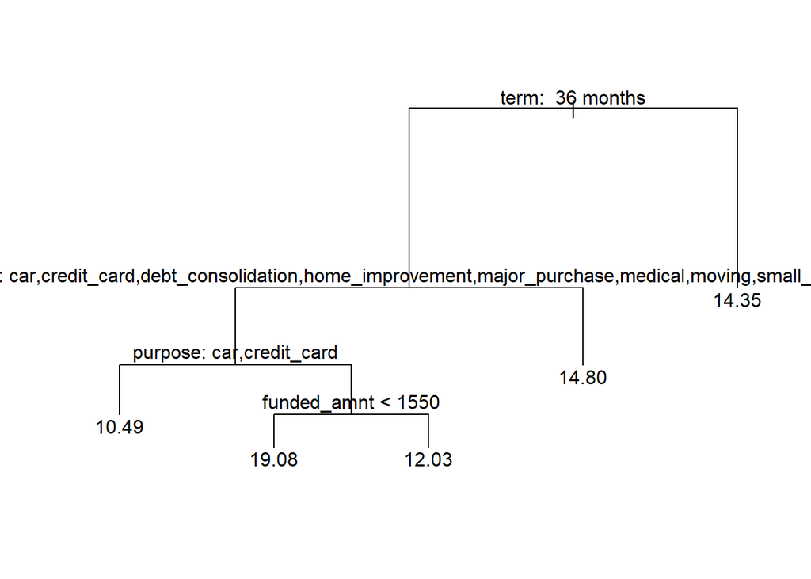

```r
plot(treelar)
text(treelar, pretty=0)
```

```r
preds = predict(treelar, newdata = loans_testlar)
mean((loans_testlar$int_rate - preds)^2)
```

```
## [1] 21.60858
```

```r
summary(treelar)
```

```
##
## Regression tree:
## tree(formula = int_rate ~ ., data = loans_trainlar)
## Variables actually used in tree construction:
## [1] "term"        "purpose"     "funded_amnt"
## Number of terminal nodes:  5
## Residual mean deviance:  20.27 = 92970 / 4586
## Distribution of residuals:
##     Min.  1st Qu.   Median     Mean  3rd Qu.     Max.
## -11.5200  -3.4720  -0.7868   0.0000   2.5630  16.7800
```

## Random Forests

```r
set.seed(1)

rfmed = randomForest(int_rate~., data = loans_trainmed)
yhat.rfmed = predict(rfmed, newdata = loans_testmed)
mean((yhat.rfmed - loans_testmed$int_rate)^2)
```

```
## [1] 19.42147
```

```r
rfsm = randomForest(int_rate~., data = loans_trainsm)
yhat.rfsm = predict(rfsm, newdata = loans_testsm)
mean((yhat.rfsm - loans_testsm$int_rate)^2)
```

```
## [1] 20.09872
```

```r
rfmain = randomForest(int_rate~., data = loans_trainlar)
yhat.rf = predict(rfmain, newdata = loans_testlar)
mean((yhat.rf - loans_testlar$int_rate)^2)
```

```
## [1] 18.79377
```

Using the default values of the parameters, the models perfrom in order of size, with the largest doing the best and the smallest doing the worst.

```r
#Tuning M
set.seed(1)
bestm = tuneRF(loans_trainlar[,-3], loans_trainlar$int_rate, stepFactor = 2)
```

```
## mtry = 4  OOB error = 18.88802
## Searching left ...
## mtry = 2     OOB error = 18.9635
## -0.003996366 0.05
## Searching right ...
## mtry = 8     OOB error = 18.86952
## 0.0009796192 0.05
```

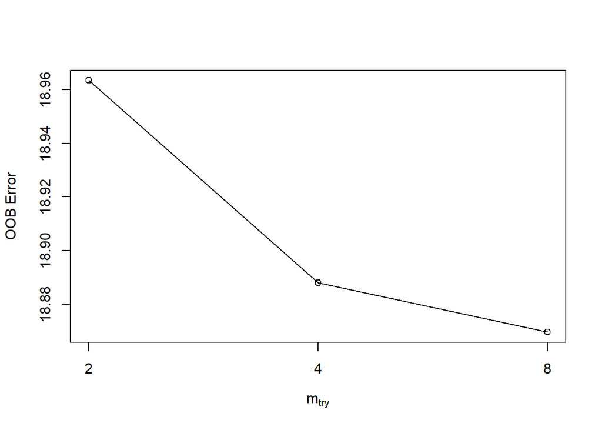

```r
bestmmed = tuneRF(loans_trainmed[,-3], loans_trainmed$int_rate, stepFactor = 2)
```

```
## mtry = 4  OOB error = 20.81444
## Searching left ...
## mtry = 2     OOB error = 21.00872
## -0.009333742 0.05
## Searching right ...
## mtry = 8     OOB error = 21.76381
## -0.04561085 0.05
```

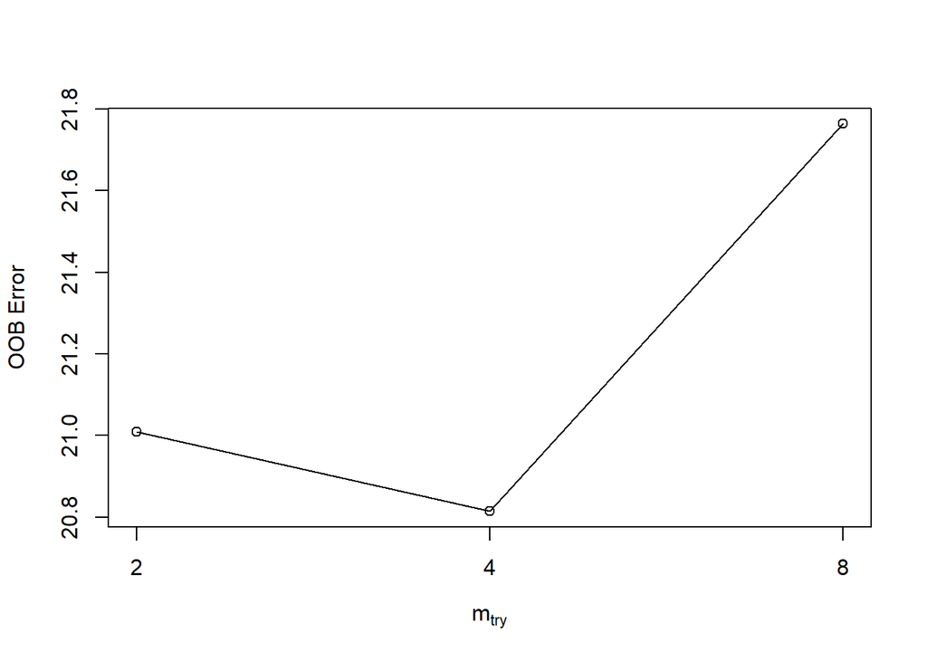

```r
bestmsm = tuneRF(loans_trainsm[,-3], loans_trainsm$int_rate, stepFactor = 2)
```

```
## mtry = 4  OOB error = 19.35294
## Searching left ...
## mtry = 2     OOB error = 19.89161
## -0.02783444 0.05
## Searching right ...
## mtry = 8     OOB error = 19.08741
## 0.01372037 0.05
```

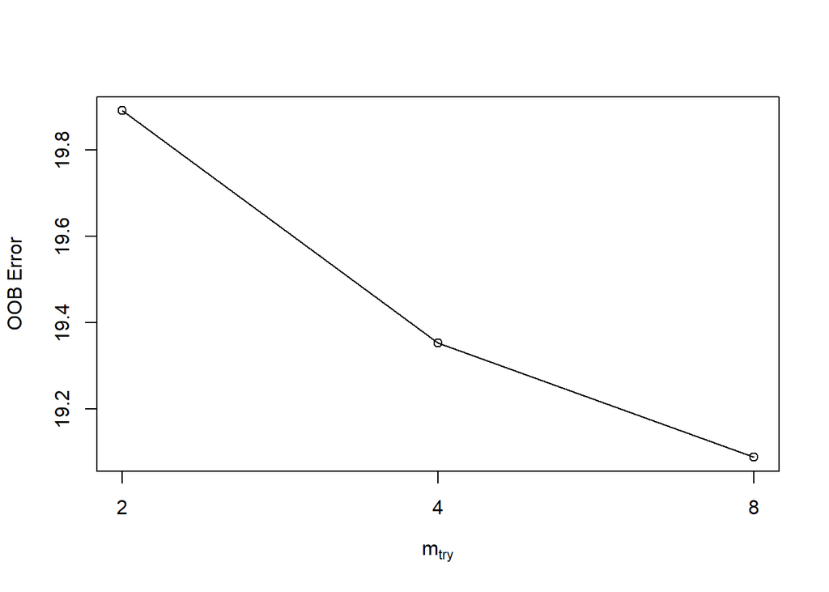

```r
bestm
```

```
##   mtry OOBError
## 2    2 18.96350
## 4    4 18.88802
## 8    8 18.86952
```

```r
bestmmed
```

```
##   mtry OOBError
## 2    2 21.00872
## 4    4 20.81444
## 8    8 21.76381
```

```r
bestmsm
```

```
##   mtry OOBError
## 2    2 19.89161
## 4    4 19.35294
## 8    8 19.08741
```

```r
set.seed(1)
rfmain = randomForest(int_rate~., data = loans_trainlar, mtry = 2)
yhat.rf = predict(rfmain, newdata = loans_testlar)
summary(rfmain)
```

```
##                 Length Class  Mode
## call               4   -none- call
## type               1   -none- character
## predicted       4591   -none- numeric
## mse              500   -none- numeric
## rsq              500   -none- numeric
## oob.times       4591   -none- numeric
## importance        12   -none- numeric
## importanceSD       0   -none- NULL
## localImportance    0   -none- NULL
## proximity          0   -none- NULL
## ntree              1   -none- numeric
## mtry               1   -none- numeric
## forest            11   -none- list
## coefs              0   -none- NULL
## y               4591   -none- numeric
## test               0   -none- NULL
## inbag              0   -none- NULL
## terms              3   terms  call
```

```r
mean((yhat.rf - loans_test$int_rate)^2)
```

```
## [1] 26.97342
```

```r
rfmed = randomForest(int_rate~., data = loans_trainmed, mtry = 2)
yhat.rfmed = predict(rfmed, newdata = loans_testmed)
summary(rfmed)
```

```
##                 Length Class  Mode
## call               4   -none- call
## type               1   -none- character
## predicted       1000   -none- numeric
## mse              500   -none- numeric
## rsq              500   -none- numeric
## oob.times       1000   -none- numeric
## importance        12   -none- numeric
## importanceSD       0   -none- NULL
## localImportance    0   -none- NULL
## proximity          0   -none- NULL
## ntree              1   -none- numeric
## mtry               1   -none- numeric
## forest            11   -none- list
## coefs              0   -none- NULL
## y               1000   -none- numeric
## test               0   -none- NULL
## inbag              0   -none- NULL
## terms              3   terms  call
```

```r
mean((yhat.rfmed - loans_testmed$int_rate)^2)
```

```
## [1] 19.32395
```

```r
rfsm = randomForest(int_rate~., data = loans_trainsm, mtry =8)
yhat.rfsm = predict(rfsm, newdata = loans_testsm)
summary(rfsm)
```

```
##                 Length Class  Mode
## call              4    -none- call
## type              1    -none- character
## predicted       500    -none- numeric
## mse             500    -none- numeric
## rsq             500    -none- numeric
## oob.times       500    -none- numeric
## importance       12    -none- numeric
## importanceSD      0    -none- NULL
## localImportance   0    -none- NULL
## proximity         0    -none- NULL
## ntree             1    -none- numeric
## mtry              1    -none- numeric
## forest           11    -none- list
## coefs             0    -none- NULL
## y               500    -none- numeric
## test              0    -none- NULL
## inbag             0    -none- NULL
## terms             3    terms  call
```

```r
mean((yhat.rfsm - loans_testsm$int_rate)^2)
```

```
## [1] 20.16293
```

## GAM

We can fit a general additive model using splines to our model Since we determined that only annual_inc may have a non-linear relation ship with int_rate, we can fit it with a smoothing spline and add it to our model

### GAM n = 500

```r
gam_small <- gam(int_rate ~ funded_amnt + term + home_ownership + s(annual_inc, df = 4) + verification_status + purpose + delinq_2yrs + earliest_cr_line + revol_bal + initial_list_status + acc_open_past_24mths + num_sats, data = loans_trainsm)
summary(gam_small)
```

```
##
## Call: gam(formula = int_rate ~ funded_amnt + term + home_ownership +
##     s(annual_inc, df = 4) + verification_status + purpose + delinq_2yrs +
##     earliest_cr_line + revol_bal + initial_list_status + acc_open_past_24mths +
##     num_sats, data = loans_trainsm)
## Deviance Residuals:
##    Min     1Q Median     3Q    Max
## -8.414 -2.754 -0.877  1.960 16.238
##
## (Dispersion Parameter for gaussian family taken to be 17.7668)
##
##     Null Deviance: 10326.03 on 499 degrees of freedom
## Residual Deviance: 8368.173 on 470.9999 degrees of freedom
## AIC: 2887.73
##
## Number of Local Scoring Iterations: 2
##
## Anova for Parametric Effects
##                        Df Sum Sq Mean Sq F value    Pr(>F)
## funded_amnt             1    2.6    2.62  0.1474 0.7011893
## term                    1  511.8  511.77 28.8048 1.259e-07 ***
## home_ownership          3  136.9   45.64  2.5691 0.0537572 .
## s(annual_inc, df = 4)   1    9.9    9.90  0.5574 0.4556712
## verification_status     2  375.7  187.86 10.5734 3.222e-05 ***
## purpose                11  533.5   48.50  2.7299 0.0019768 **
## delinq_2yrs             1   10.2   10.24  0.5761 0.4482071
## earliest_cr_line        1  107.1  107.08  6.0271 0.0144483 *
## revol_bal               1    0.1    0.05  0.0030 0.9562986
## initial_list_status     1   17.3   17.28  0.9725 0.3245574
## acc_open_past_24mths    1  211.5  211.45 11.9014 0.0006114 ***
## num_sats                1    6.3    6.33  0.3565 0.5507268
## Residuals             471 8368.2   17.77
## ---
## Signif. codes:  0 '***' 0.001 '**' 0.01 '*' 0.05 '.' 0.1 ' ' 1
##
## Anova for Nonparametric Effects
##                       Npar Df  Npar F  Pr(F)
## (Intercept)
## funded_amnt
## term
## home_ownership
## s(annual_inc, df = 4)       3 0.61499 0.6056
## verification_status
## purpose
## delinq_2yrs
## earliest_cr_line
## revol_bal
## initial_list_status
## acc_open_past_24mths
## num_sats
```

```r
gam_small.preds=predict(gam_small,newdata = loans_testsm)
mean((loans_testsm$int_rate - gam_small.preds) ^ 2)
```

```
## [1] 19.95916
```

From the summary output above, the spline has a p-value of 0.456, making it not a very significant piece of the model. When the GAM with the spline is compared to the GAM without the spline, there seems to be no evidence of significant different (p-val = 0.6) as shown by the ANOVA output.

### GAM n = 1000

```r
gam_med <- gam(int_rate ~ funded_amnt + term + home_ownership + s(annual_inc, df = 4) + verification_status + purpose + delinq_2yrs + earliest_cr_line + revol_bal + initial_list_status + acc_open_past_24mths + num_sats, data = loans_trainmed)
summary(gam_med)
```

```
##
## Call: gam(formula = int_rate ~ funded_amnt + term + home_ownership +
##     s(annual_inc, df = 4) + verification_status + purpose + delinq_2yrs +
##     earliest_cr_line + revol_bal + initial_list_status + acc_open_past_24mths +
##     num_sats, data = loans_trainmed)
## Deviance Residuals:
##     Min      1Q  Median      3Q     Max
## -8.2819 -3.1352 -0.8281  2.3939 16.3507
##
## (Dispersion Parameter for gaussian family taken to be 19.1238)
##
##     Null Deviance: 23676.67 on 999 degrees of freedom
## Residual Deviance: 18569.24 on 970.9998 degrees of freedom
## AIC: 5819.384
##
## Number of Local Scoring Iterations: 2
##
## Anova for Parametric Effects
##                        Df  Sum Sq Mean Sq F value    Pr(>F)
## funded_amnt             1    35.0   34.95  1.8276 0.1767293
## term                    1  1124.5 1124.49 58.8004 4.228e-14 ***
## home_ownership          3   353.4  117.80  6.1598 0.0003787 ***
## s(annual_inc, df = 4)   1   133.8  133.81  6.9968 0.0082973 **
## verification_status     2   818.6  409.29 21.4018 8.023e-10 ***
## purpose                11  1486.0  135.09  7.0641 1.299e-11 ***
## delinq_2yrs             1   420.3  420.31 21.9785 3.151e-06 ***
## earliest_cr_line        1   140.7  140.68  7.3560 0.0068020 **
## revol_bal               1    42.2   42.21  2.2071 0.1376985
## initial_list_status     1    23.5   23.53  1.2305 0.2675903
## acc_open_past_24mths    1   372.1  372.12 19.4584 1.143e-05 ***
## num_sats                1    81.6   81.57  4.2652 0.0391664 *
## Residuals             971 18569.2   19.12
## ---
## Signif. codes:  0 '***' 0.001 '**' 0.01 '*' 0.05 '.' 0.1 ' ' 1
##
## Anova for Nonparametric Effects
##                       Npar Df Npar F  Pr(F)
## (Intercept)
## funded_amnt
## term
## home_ownership
## s(annual_inc, df = 4)       3 2.0481 0.1055
## verification_status
## purpose
## delinq_2yrs
## earliest_cr_line
## revol_bal
## initial_list_status
## acc_open_past_24mths
## num_sats
```

```r
gam_med.preds=predict(gam_med,newdata = loans_testmed)
mean((loans_testmed$int_rate - gam_med.preds) ^ 2)
```

```
## [1] 19.58791
```

The spline was much more helpful for the medium data set than the small data set. The p-value of the spline decreased to about 0.008 and the GAM with the spline was almost significantly better (p = 0.1055) than the GAM without the spline at the 0.1 significance level. The test error also decreased from 19.96 to 19.59.

### GAM n = 4591

```r
gam_large <- gam(int_rate ~ funded_amnt + term + home_ownership + s(annual_inc, df = 4) + verification_status + purpose + delinq_2yrs + earliest_cr_line + revol_bal + initial_list_status + acc_open_past_24mths + num_sats, data = loans_trainlar)
summary(gam_large)
```

```
##
## Call: gam(formula = int_rate ~ funded_amnt + term + home_ownership +
##     s(annual_inc, df = 4) + verification_status + purpose + delinq_2yrs +
##     earliest_cr_line + revol_bal + initial_list_status + acc_open_past_24mths +
##     num_sats, data = loans_trainlar)
## Deviance Residuals:
##     Min      1Q  Median      3Q     Max
## -12.483  -3.065  -0.852   2.265  16.524
##
## (Dispersion Parameter for gaussian family taken to be 18.268)
##
##     Null Deviance: 104669.6 on 4590 degrees of freedom
## Residual Deviance: 83338.6 on 4562 degrees of freedom
## AIC: 26397.15
##
## Number of Local Scoring Iterations: 2
##
## Anova for Parametric Effects
##                         Df Sum Sq Mean Sq  F value    Pr(>F)
## funded_amnt              1     79    78.7   4.3070 0.0380118 *
## term                     1   8238  8237.6 450.9283 < 2.2e-16 ***
## home_ownership           3    954   318.1  17.4142 3.067e-11 ***
## s(annual_inc, df = 4)    1    216   216.5  11.8487 0.0005822 ***
## verification_status      2   3082  1540.8  84.3436 < 2.2e-16 ***
## purpose                 11   4563   414.8  22.7054 < 2.2e-16 ***
## delinq_2yrs              1    954   953.8  52.2142 5.804e-13 ***
## earliest_cr_line         1    430   430.2  23.5518 1.257e-06 ***
## revol_bal                1    192   192.0  10.5122 0.0011944 **
## initial_list_status      1    149   148.9   8.1499 0.0043258 **
## acc_open_past_24mths     1   1679  1679.4  91.9289 < 2.2e-16 ***
## num_sats                 1    481   480.8  26.3215 3.010e-07 ***
## Residuals             4562  83339    18.3
## ---
## Signif. codes:  0 '***' 0.001 '**' 0.01 '*' 0.05 '.' 0.1 ' ' 1
##
## Anova for Nonparametric Effects
##                       Npar Df Npar F   Pr(F)
## (Intercept)
## funded_amnt
## term
## home_ownership
## s(annual_inc, df = 4)       3 2.7512 0.04117 *
## verification_status
## purpose
## delinq_2yrs
## earliest_cr_line
## revol_bal
## initial_list_status
## acc_open_past_24mths
## num_sats
## ---
## Signif. codes:  0 '***' 0.001 '**' 0.01 '*' 0.05 '.' 0.1 ' ' 1
```

```r
gam_large.preds=predict(gam_large, newdata = loans_testlar)
mean((loans_testlar$int_rate - gam_large.preds) ^ 2)
```

```
## [1] 19.47326
```

The spline was much more helpful for the large data set than the medium and small data sets. The GAM with the spline had evidence sugesting that it is significantly better (p = 0.041) than the GAM without the splinel. The test error also decreased slighlty from the medium data set and greatly from the small dataset (19.96 -> 19.59 -> 19.47).

## Boosting

For boosting, we must determine the optimal tuning parameter lambda through cross validation.

### Boosting n = 500

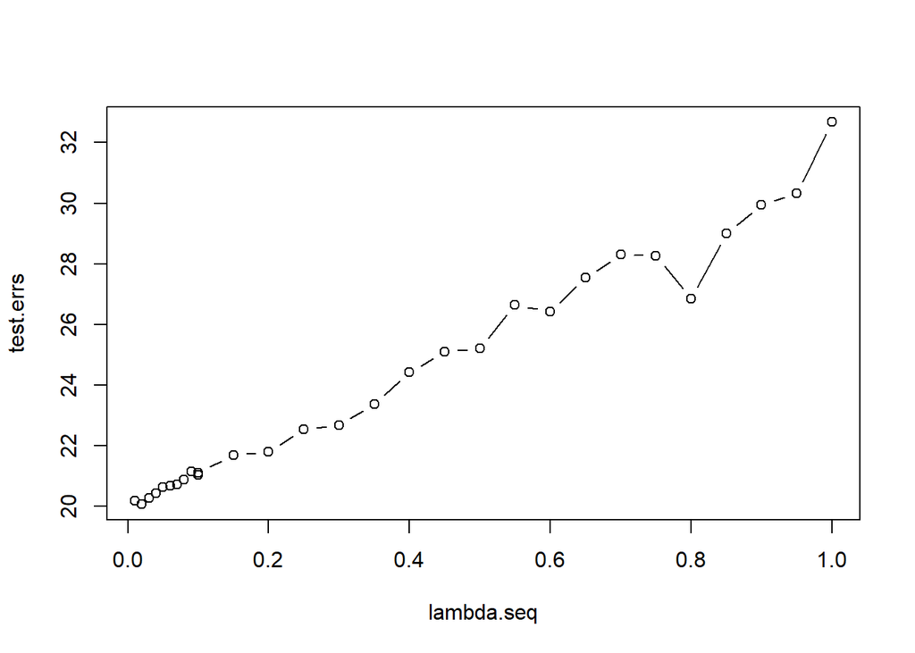

```r
set.seed(1)
lambda.seq <- c(seq(from = .01, to = .1, by = .01), seq(from = .1, to = 1, by = .05))
test.errs <- numeric(length(lambda.seq))

for (i in 1:length(lambda.seq)) {
    boost.interest <- gbm(int_rate~., data = loans_trainsm, distribution = "gaussian",
                         n.trees = 1000, shrinkage = lambda.seq[i])
    yhat.boost <- predict(boost.interest, newdata = loans_testsm, n.trees = 1000)
    test.errs[i] <- mean((yhat.boost - loans_testsm$int_rate)^2)
}
plot(lambda.seq, test.errs, type = "b")
```

```r
tab_matrix = matrix(nrow = 3, ncol = 2)
colnames(tab_matrix) = c("lambda", "test error")
rownames(tab_matrix) = c("training n=500", "training n=1000", "training n=4591")
tab_matrix[1,1] = lambda.seq[which.min(test.errs)]
tab_matrix[1,2] = min(test.errs)

lambda.seq[which.min(test.errs)]
```

```
## [1] 0.02
```

```r
min(test.errs)
```

```
## [1] 20.05818
```

For the small training set, the best lambda is 0.02 and it has a test error of 20.06.

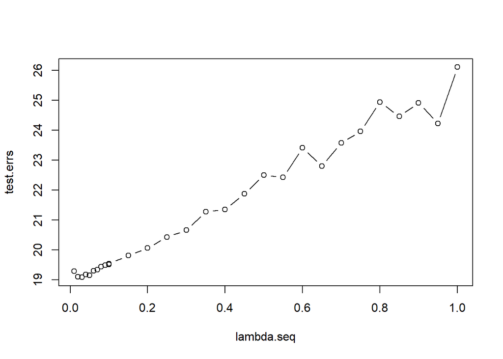

```r
set.seed(1)
test.errs <- numeric(length(lambda.seq))

for (i in 1:length(lambda.seq)) {
    boost.interest <- gbm(int_rate~., data = loans_trainmed, distribution = "gaussian",
                         n.trees = 1000, shrinkage = lambda.seq[i])
    yhat.boost <- predict(boost.interest, newdata = loans_testmed, n.trees = 1000)
    test.errs[i] <- mean((yhat.boost - loans_testmed$int_rate)^2)
}
plot(lambda.seq, test.errs, type = "b")
```

```r
tab_matrix[2,1] = lambda.seq[which.min(test.errs)]
tab_matrix[2,2] = min(test.errs)

lambda.seq[which.min(test.errs)]
```

```
## [1] 0.03
```

```r
min(test.errs)
```

```
## [1] 19.08869
```

For the medium training set, the best lambda is 0.03 and it has a test error of 19.089 down from the 20.06 of the small set.

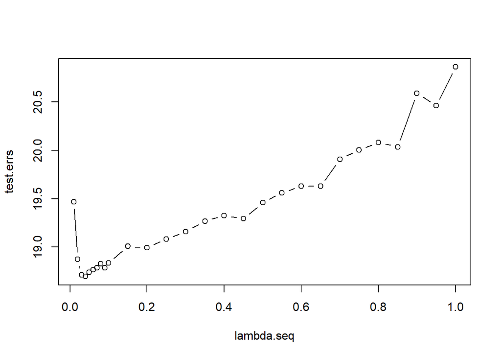

```r
set.seed(1)
test.errs <- numeric(length(lambda.seq))

for (i in 1:length(lambda.seq)) {
    boost.interest <- gbm(int_rate~., data = loans_trainlar, distribution = "gaussian",
                         n.trees = 1000, shrinkage = lambda.seq[i])
    yhat.boost <- predict(boost.interest, newdata = loans_testlar, n.trees = 1000)
    test.errs[i] <- mean((yhat.boost - loans_testlar$int_rate)^2)
}
plot(lambda.seq, test.errs, type = "b")
```

```r
tab_matrix[3,1] = lambda.seq[which.min(test.errs)]
tab_matrix[3,2] = min(test.errs)

lambda.seq[which.min(test.errs)]
```

```
## [1] 0.04
```

```r
min(test.errs)
```

```
## [1] 18.69684
```

For the large training set, the best lambda is 0.04 and it has a test error of 18.697 which is better than medium and small.

```r
tab_matrix
```

```
##                 lambda test error
## training n=500    0.02   20.05818
## training n=1000   0.03   19.08869
## training n=4591   0.04   18.69684
```

## Neural Networks

### Neural Networks n = 500

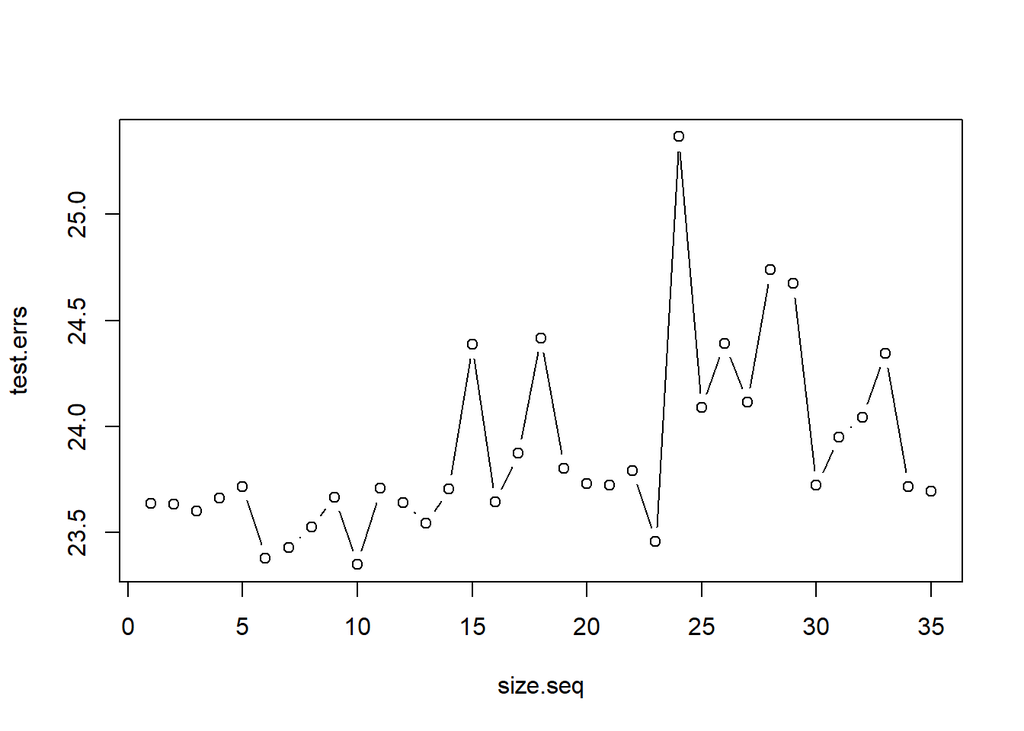

```r
set.seed(1)
size.seq <- seq(1,35, by = 1)
test.errs <- numeric(length(size.seq))

for(i in 1:length(size.seq)){
loans.nn <- nnet(int_rate~., data = loans_trainsm, size = size.seq[i],
                   linout = TRUE, trace = FALSE)

yhat.nn <- predict(loans.nn, newdata = loans_testsm)
test.errs[i] <- mean((yhat.nn - loans_testsm$int_rate)^2)
}

colnames(tab_matrix) = c("size", "test error")
rownames(tab_matrix) = c("training n=500", "training n=1000", "training n=4591")

tab_matrix[1,1] = size.seq[which.min(test.errs)]
tab_matrix[1,2] = min(test.errs)
plot(size.seq, test.errs, type = "b")
```

The best number of hidden units for the small training set is 10 and the test error is 23.35.

```r
set.seed(1)
test.errs <- numeric(length(size.seq))

for(i in 1:length(size.seq)){
loans.nn <- nnet(int_rate~., data = loans_trainmed, size = size.seq[i],
                   linout = TRUE, trace = FALSE)

yhat.nn <- predict(loans.nn, newdata = loans_testmed)
test.errs[i] <- mean((yhat.nn - loans_testmed$int_rate)^2)
}


tab_matrix[2,1] = size.seq[which.min(test.errs)]
tab_matrix[2,2] = min(test.errs)

size.seq[which.min(test.errs)]
```

```
## [1] 6
```

```r
min(test.errs)
```

```
## [1] 23.07545
```

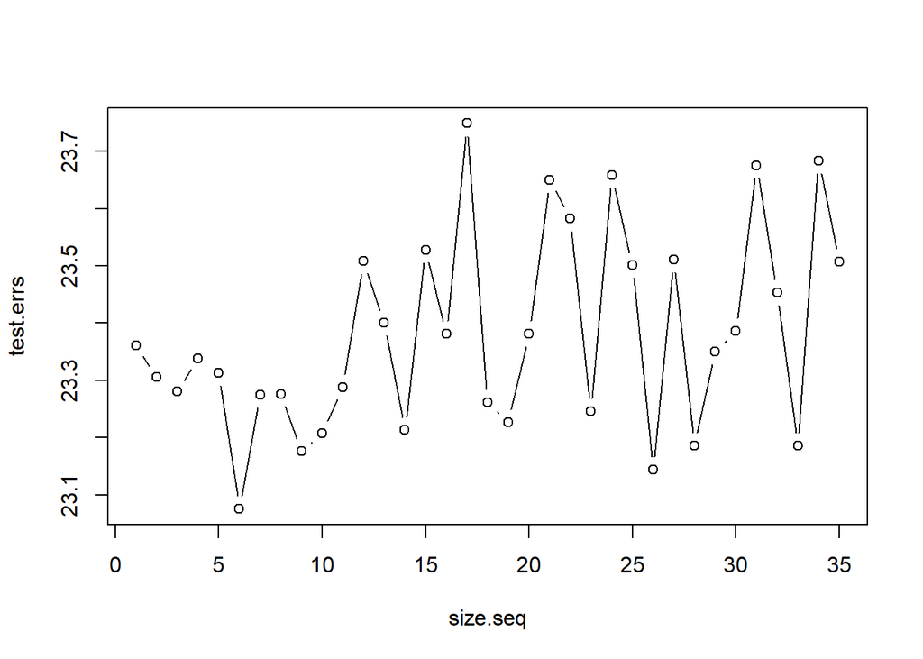

```r
plot(size.seq, test.errs, type = "b")
```

The best number of hidden units for the medium sized training set is 6 and the test error is 23.08

```r
set.seed(1)
test.errs <- numeric(length(size.seq))

for(i in 1:length(size.seq)){
loans.nn <- nnet(int_rate~., data = loans_trainlar, size = size.seq[i],
                   linout = TRUE, trace = FALSE)

yhat.nn <- predict(loans.nn, newdata = loans_testlar)
test.errs[i] <- mean((yhat.nn - loans_testlar$int_rate)^2)
}


tab_matrix[3,1] = size.seq[which.min(test.errs)]
tab_matrix[3,2] = min(test.errs)

size.seq[which.min(test.errs)]
```

```
## [1] 26
```

```r
min(test.errs)
```

```
## [1] 23.47572
```

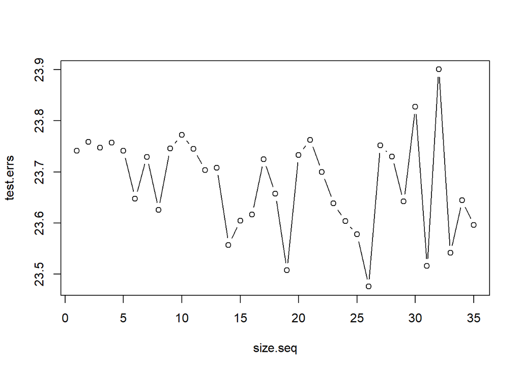

```r
plot(size.seq, test.errs, type = "b")
```

The best size for the large training set is 26 and the test error is 23.476

```r
tab_matrix
```

```
##                 size test error
## training n=500    10   23.34955
## training n=1000    6   23.07545
## training n=4591   26   23.47572
```

The neural network had test errors that were high reletive to the other methods. Also, it is one of the only methods that had a test error increase when the training set size increased.

## KNN and Principal Components Regression

We wanted to include a note on these two models, as they were among the ones we considered for analysis. As are possible with categorical variables, and we had multiple variables with many categorical levels, we determined KNN and PC Regression were not suitable models for our dataset.